# FordGoBike Exploration

### Duration vs Start Time

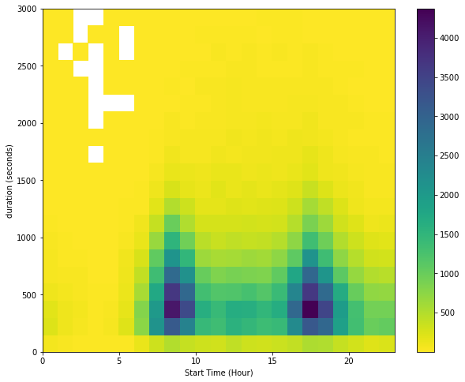

```python
# creating a heatmap between duration and start time
plt.figure(figsize = (10,8))
bins_x = np.arange(0, 23+1, 1)
bins_y = np.arange(0, 3000+150, 150)
plt.hist2d(data = ford_vlim, x = 'start_hour', y = 'duration_sec', cmin = 0.5,
          cmap = 'viridis_r', bins = [bins_x, bins_y]);
plt.colorbar()
plt.xlabel('Start Time (Hour)')
plt.ylabel('duration (seconds)')
```

This tells us that there are two very similar hot spots centred around 8-9am and 17:00-18:00pm. We know that these are 'rush hour' times, so it is likely that the hig volume of cyclists at these hours, cycling for short durations ranging from 150 to 1000 seconds, are people cycling to and from work, which is actually opposite of what I suspected, as I though the need to cycle to work may increase cycling duration.

### member age and duration

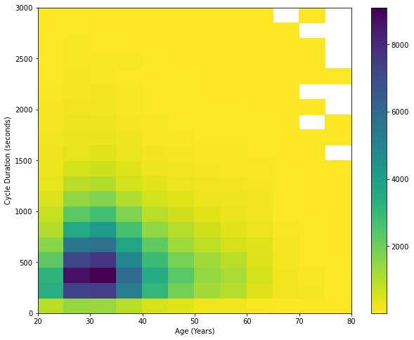

```python
# creating a heat map between member age and duration
plt.figure(figsize = (10,8))
bins_x = np.arange(20, 80+5, 5)
bins_y = np.arange(0, 3000+5, 150)
plt.hist2d(data = ford_clean, x = 'member_age', y = 'duration_sec', cmin = 0.5,
          cmap = 'viridis_r', bins = [bins_x, bins_y]);
plt.colorbar()
plt.xlabel('Age (Years)')
plt.ylabel('Cycle Duration (seconds)')
```

Can see that the most frequently occuring duration is the 300-400 second duration for members between the ages of 25 and 35. It makes sense for this age group to be the one with the most occurences at a given point on this graph because we saw from univariate age plot that these were the most prominent age groups, comprising of more than a quarter of the dataset. It also serves as further evidence of the work theory: given that this is a common age for professionals in the workplace, it suggests that the high volume of sub ten minute cycles among these age groups could be due to the higher propensity for these age groups to cycle to work.

### Member Age (Years) vs Start Time (Digital Hour)

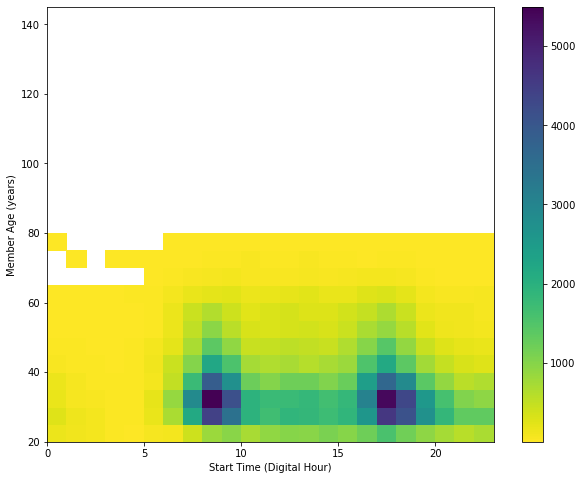

```python
# problem with this as it is dicrete to discrete.
plt.figure(figsize = (10,8))
bins_x = np.arange(0, 23+1, 1)
bins_y = np.arange(20, 145+5, 5)
plt.hist2d(data = ford_clean, x = 'start_hour', y = 'member_age', cmin = 0.5,
          cmap = 'viridis_r', bins = [bins_x, bins_y]);
plt.colorbar()
plt.xlabel('Start Time (Digital Hour)')
plt.ylabel('Member Age (years)')
```

### Duration vs Categorical Variables

#### Duration vs User Type

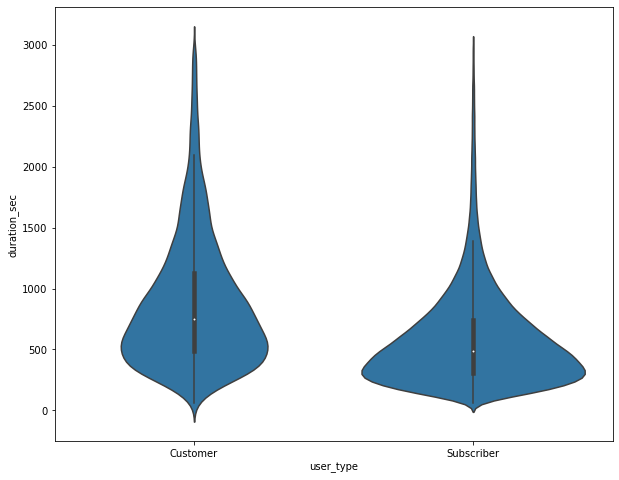

```python
plt.figure(figsize=(10,8))
base_color = sb.color_palette()[0]
sb.violinplot(data = ford_vlim, x = 'user_type', y = 'duration_sec',
              color=base_color);
```

Looking at the above violin plot, we can see that subscribers appear to cyce for much shorter durations than customers, with a large volume cycling for less than 500 seconds. It could be that there is overlap between the number of subcribers and the cyclist riding to work, as they would be more likley to subscribe if they use the ford bikes as a daily transportation system. I want to explore this further using faceting.

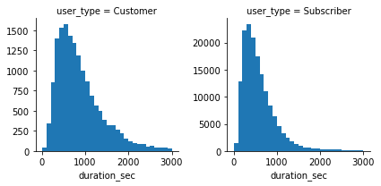

```python
bins = np.arange(0, 3000+100, 100)
g = sb. FacetGrid(data =  ford_vlim, col = 'user_type', sharey = False)
g.map(plt.hist, 'duration_sec', bins = bins)
```

quite interesting. Can definitely see here that the subsribers are skewed more to the left, with a peak of 300-400 seconds compred to 500-600 seconds for customers. Can also see that the number of subscribers who ride longer than 1000 seconds is 1/5 of the value of the peak duration, whilst the number of cyclists riding for at least 1000 seconds amongst customers is 2/3 of the peak duration, which is a marked difference.

Whilst this marries up with the cycling time taken by those travelling to work in the heat maps above, it is not what I expected. I thought subscribers would cycle longer as they would be more likely to use the service as a means of getting to work, which I assumed would take on average half an hour. It seems from the plot though that somewhere around the 6-8 minute mark seems to be by far the most common duration gor a a cyclist. I also want to take a quick look at the comparison between the averages for the two user types.

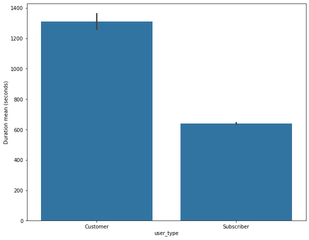

```python
# creating a bar chart for the average duration for the two user types:
plt.figure(figsize=(10,8))
base_color = sb.color_palette()[0]
sb.barplot(data = ford_clean, x = 'user_type', y = 'duration_sec',
              color=base_color);
plt.ylabel('Duration mean (seconds)')
```

This is a resounding difference, and one that couldn't have been seen from the violin plot above. As a result it suggests that customers are more likely than subscribers to go on very long cycles, which is what makes the difference in the means higher than that of their medians.